# Data manipulation in R

Originally prepared by JOSHUA MADIN “http://acropora.bio.mq.edu.au/resources/introduction-to-r/graphing/”" - MODIFIED BY M. KOSNIK

28 October 2017

## WE NEED SOME DATA TO PLAY WITH

Individual bivalves collected from soft sediment at One Tree Reef with measurements. This is a similified version of the data related to this research:

```
Julieta C. Martinelli, Matthew A. Kosnik, And Joshua S. Madin
Passive Defensive Traits Are Not Good Predictors Of Predation For Infaunal Reef Bivalves
PALAIOS, 2016, v. 31, 607â 615 . http://dx.doi.org/10.2110/palo.2016.018

Matthew A. Kosnik, Quan Hua, Darrell S. Kaufman, Atun Zawadzki
Sediment accumulation, stratigraphic order, and the extent of time-averaging in lagoonal sediments:
a comparison of 210Pb and 14C/amino acid racemization chronologies
Coral Reefs (2015) 34:215â 229. http://dx.doi.org/10.1007/s00338-014-1234-2
```

## READ A TAB DELIMITED FILE ‘./data/oti_measurements.txt’

```r
otiShells <- read.delim('./data/oti_measurements.txt')
```

## WHAT HAVE WE GOT HERE?

```r
head(otiShells)
```

```
##               taxonName siteName  x_mm y_mm z_mm mass_mg
## 1 Pinguitellina robusta      2nd  9.84 8.36 2.34  110.96
## 2 Pinguitellina robusta      2nd  8.02 6.63 1.55   50.57
## 3 Pinguitellina robusta      2nd  6.47 5.15 1.39   28.20
## 4     Exotica clathrata      2nd 11.18 5.87 1.55   39.60
## 5     Exotica clathrata      2nd 12.83 6.62 1.80   74.19
## 6     Exotica clathrata      2nd 10.80 5.90 1.53   45.62
```

```r
summary(otiShells)      # ANYTHING FISHY?
```

```
##                  taxonName    siteName        x_mm            y_mm
##  Abranda jeanae       :1469   1st:1925   Min.   : 0.00   Min.   : 0.000
##  Pinguitellina robusta: 710   2nd: 908   1st Qu.: 8.24   1st Qu.: 5.830
##  Exotica clathrata    : 522   3rd: 671   Median :10.54   Median : 7.330
##  Scissulina dispar    : 329              Mean   :11.42   Mean   : 8.088
##  Fragum fragum        : 173              3rd Qu.:13.84   3rd Qu.: 9.800
##  Ctena bella          : 138              Max.   :62.34   Max.   :36.190
##  (Other)              : 163
##       z_mm          mass_mg
##  Min.   : 0.00   0.00   : 202
##  1st Qu.: 1.38   \\N    :  46
##  Median : 1.77   11.00  :  18
##  Mean   : 1.93   14.00  :  17
##  3rd Qu.: 2.34   10.00  :  12
##  Max.   :11.85   12.00  :  12
##                  (Other):3197
```

# RE-IMPORT & CLEAN UP AS NEEDED

```r
otiShells <- read.delim('./data/oti_measurements.txt', na.strings='\\N')
otiShells <- otiShells[(otiShells$mass_mg > 0),]
otiShells <- otiShells[(otiShells$x_mm > 0),]
```

## REVIEW: DIFFERENT WAYS REFERENCE COLUMNS, SHOULD ALL WORK

```r
otiShells[1:10,"x_mm"]
```

```
##  [1]  9.84  8.02  6.47 11.18 12.83 10.80 10.20 14.32 32.95 30.98
```

```r
otiShells[["x_mm"]][1:10]
```

```
##  [1]  9.84  8.02  6.47 11.18 12.83 10.80 10.20 14.32 32.95 30.98
```

```r
otiShells$x_mm[1:10]
```

```
##  [1]  9.84  8.02  6.47 11.18 12.83 10.80 10.20 14.32 32.95 30.98
```

## IF YOU ARE GOING TO USE IT A BUNCH - MAKE A NEW COLUMN FOR THE TRANSFORMED VARIABLE

```r
otiShells$crMass <- otiShells$mass_mg^(1/3)
```

# HISTOGRAMS

```r
? hist()
```

## PLOT HISTOGRAM OF SHELL SIZE

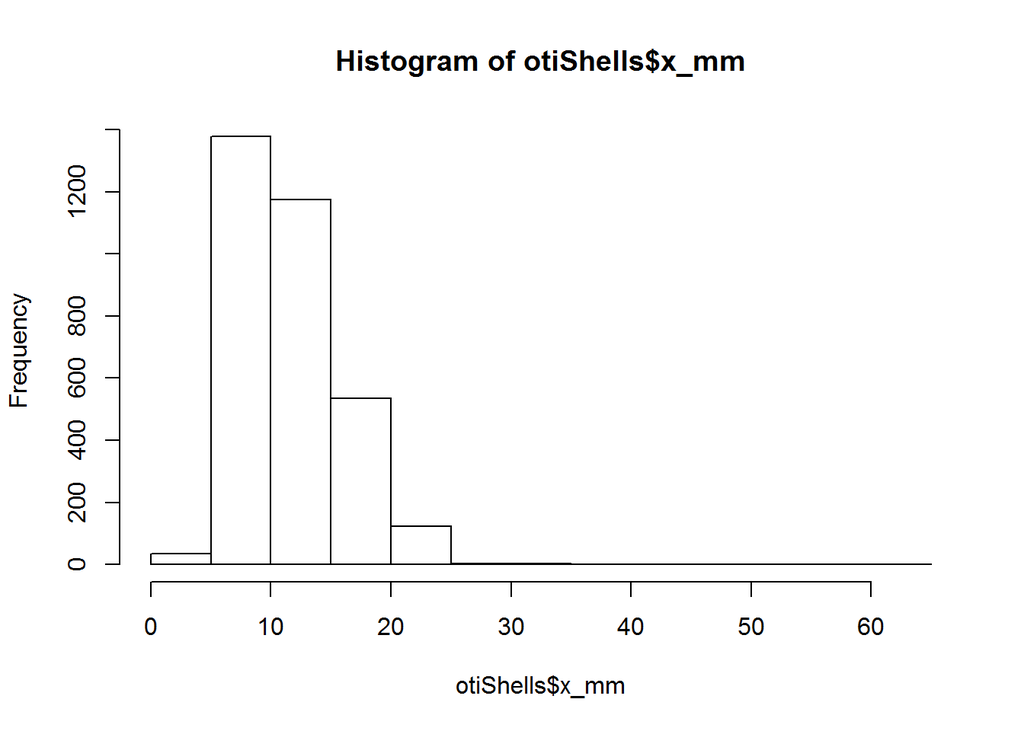

```r
hist(otiShells$x_mm)
```

## LETS ADD BETTER AXIS LABELS

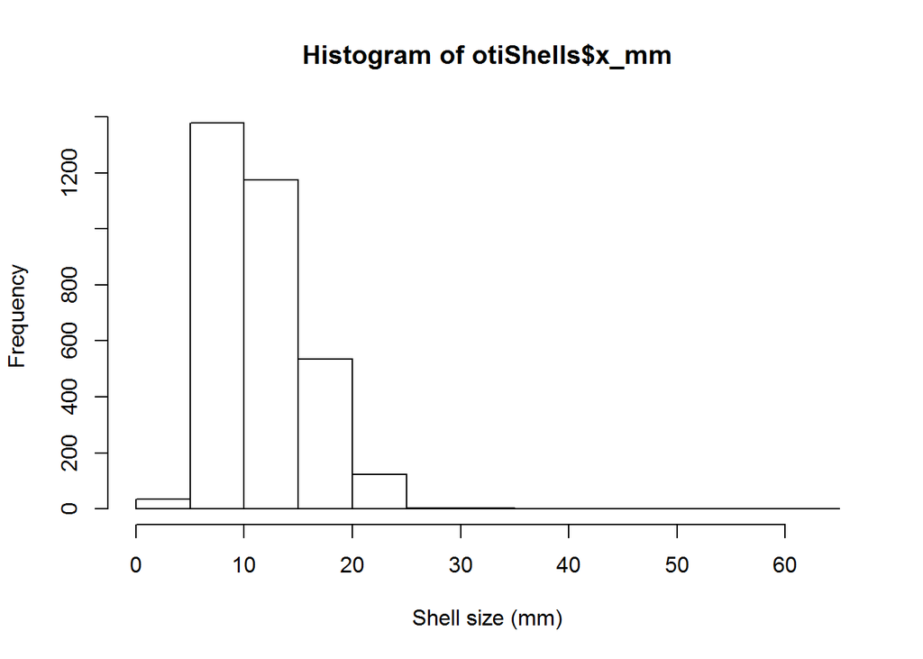

```r
hist(otiShells$x_mm, xlab='Shell size (mm)')
```

## LETS COLOUR OUR COLUMNS & ADD MAIN TITLE

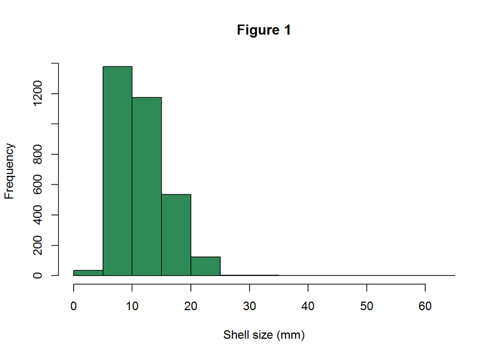

```r
hist(otiShells$x_mm, xlab='Shell size (mm)', col='seagreen', main="Figure 1")
```

## ANOTHER WAY TO SPECIFY COLOURS

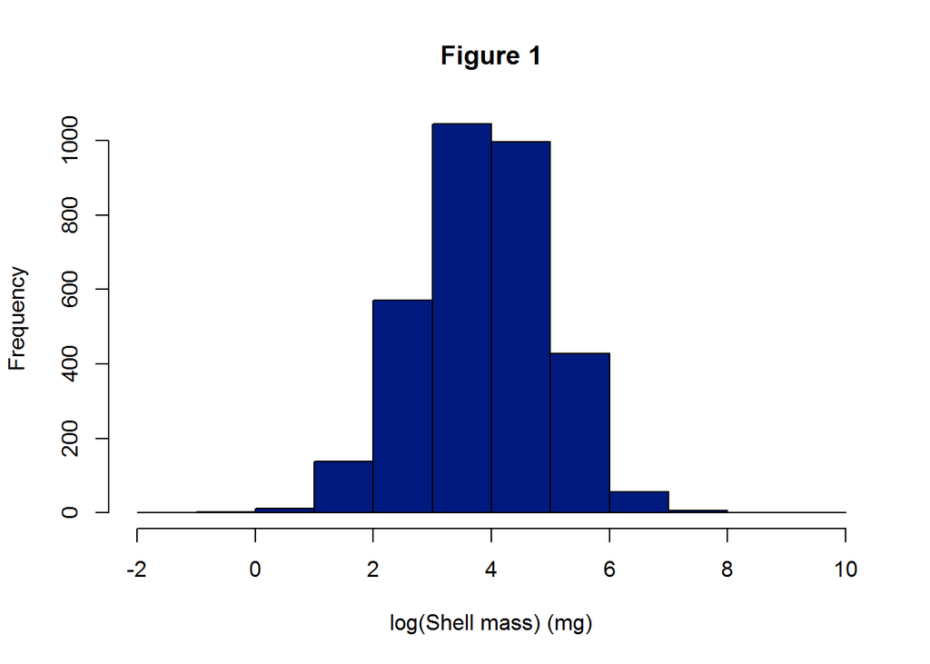

```r
hist(log(otiShells$mass_mg), xlab="log(Shell mass) (mg)", col=rgb(0,0.1,0.5), main="Figure 1")
```

**QUESTION**: which log is this?

## WHAT ELSE CAN `hist()` DO?

```r
aHist <- hist(log2(otiShells[grep('Abranda',otiShells$taxonName),'mass_mg']), plot=FALSE)
```

**QUESTION**: tell me about object aHist

```r
aHist
```

```
## $breaks
##  [1]  0  1  2  3  4  5  6  7  8  9 10
##
## $counts
##  [1]   2  12  59 143 212 301 293 290 102   9
##
## $density
##  [1] 0.001405481 0.008432888 0.041461701 0.100491918 0.148981026
##  [6] 0.211524947 0.205903022 0.203794800 0.071679550 0.006324666
##
## $mids
##  [1] 0.5 1.5 2.5 3.5 4.5 5.5 6.5 7.5 8.5 9.5
##
## $xname
## [1] "log2(otiShells[grep(\"Abranda\", otiShells$taxonName), \"mass_mg\"])"
##
## $equidist
## [1] TRUE
##
## attr(,"class")
## [1] "histogram"
```

## MAKE A HISTOGRAM FOR LOG ABRANDA SHELL MASS… WITH NO AXES OR LABELS

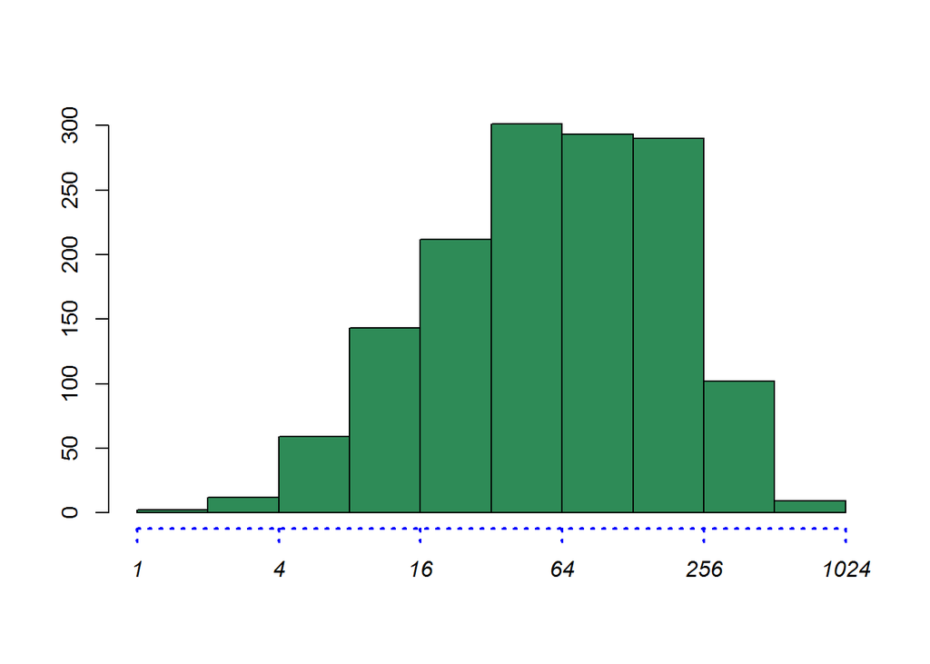

```r
plot(aHist, col='seagreen', ann=FALSE, axes=FALSE)
## ADD Y axis() MANUALLY (ALLOWS FOR GREATER CONTROL)
axis(side= 2)   # identical to what would have been drawn from hist()
## SPECIFY A COMPLEX AXIS
where <- seq(floor(min(aHist$breaks)),ceiling(max(aHist$breaks)),by=2)
what <- 2^where
axis(1, at=where, labels=what, lwd=2, lty=3, col='blue', font=3)    # specify details of line
```

```r
? axis()
```